# IE582_Fall21_Homework2

## Task 1 – Dimensionality reduction

```python
# import required libraries

import pandas as pd
import numpy as np
import matplotlib.pyplot as plt
import seaborn as sns
```

```python
data=pd.read_csv('IE582_Fall21_HW2_q1_data.csv')
data.head()
```

|  | X1 | X2 | class |
| --- | --- | --- | --- |
| 0 | 0.569483 | 0.822003 | a |
| 1 | 0.411469 | 0.911424 | a |
| 2 | 0.417385 | -0.908730 | a |
| 3 | -0.791828 | 0.610745 | a |
| 4 | -0.806777 | -0.590857 | a |

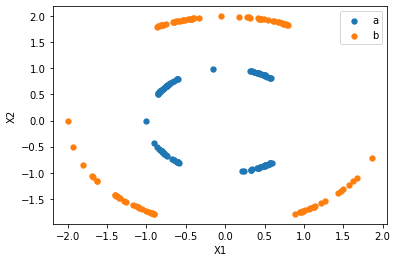

```python
#Use hot encoder to make independent variable numeric
X = data.iloc[:, :-1].values
y = data.iloc[:, -1].values
from sklearn.preprocessing import LabelEncoder
le = LabelEncoder()
y = le.fit_transform(y)

plt.scatter(X[y==0][:,0], X[y==0][:,1], lw=0, s=40, label='a')
plt.scatter(X[y==1][:,0], X[y==1][:,1], lw=0, s=40, label='b')
plt.legend()
plt.xlabel("X1")
plt.ylabel("X2")
plt.show()
```

### a) Apply PCA to reduce the number of dimensions to one and visualize the instances on a scatter plot.

```python
from sklearn.decomposition import PCA
pca = PCA(n_components = 1)
X = pca.fit_transform(X)
index =list(range(len(X)))
```

```
No handles with labels found to put in legend.
```

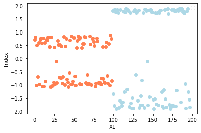

```python
for i in range(len(X)):
    if y[i]==0:
      plt.scatter(index[i],X[i],c='coral')
    else:
      plt.scatter(index[i],X[i],c='lightblue')
plt.xlabel("X1")
plt.ylabel("Index")
plt.show()
```

### b) Apply MDS to reduce the number of dimensions to one and visualize the instances on a scatter plot as in part (a).

```python
# MDS with Manhattan Distance
from sklearn.manifold import MDS
from scipy.spatial import distance_matrix
from sklearn.metrics.pairwise import manhattan_distances
l1_dist_matrix = manhattan_distances(X)
mds = MDS(n_components=1, dissimilarity="precomputed")
X = mds.fit_transform(l1_dist_matrix)
```

```
No handles with labels found to put in legend.
```

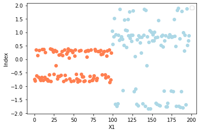

```python
for i in range(len(X)):
    if y[i]==0:
      plt.scatter(index[i],X[i],c='coral')
    else:
      plt.scatter(index[i],X[i],c='lightblue')
plt.xlabel("X1")
plt.ylabel("Index")
plt.show()
```

```python
#MDS with Euclidean Distance
mds = MDS(n_components = 1, n_jobs=-1, dissimilarity="euclidean")
X = mds.fit_transform(X)
```

```
No handles with labels found to put in legend.
```

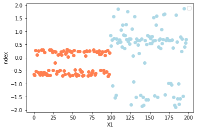

```python
for i in range(len(X)):
    if y[i]==0:
      plt.scatter(index[i],X[i],c='coral')
    else:
      plt.scatter(index[i],X[i],c='lightblue')
plt.xlabel("X1")
plt.ylabel("Index")
plt.show()
```

### c) On a 2D scatter plot, one can observe how two observations from two classes are different.

A) We use PCA to find correlations in features. However, there is no linearity in the graphs. After applying PCA, we can see that it is projected with respect to the X2 axis because X2 has higher variance than X1.

C) Although all the results were close to each other, the L1 form made the most significant distinction, while PCA was worse than the others. MDS handles nonlinearity better. The use of distance information made this difference.

### d) Suppose, you are not satisfied with your dimensionality reduction scheme in part (a).

```python
data["X1^2"] = data.X1**2
data["X2^2"] = data.X2**2
data["X1*X2"] = data.X1 * data.X2
data.drop(["class"],axis=1, inplace=True)
```

```python
print(data)
```

```
           X1        X2      X1^2      X2^2     X1*X2
0    0.569483  0.822003  0.324311  0.675689  0.468117
1    0.411469  0.911424  0.169307  0.830693  0.375023
2    0.417385 -0.908730  0.174210  0.825790 -0.379290
3   -0.791828  0.610745  0.626991  0.373009 -0.483604
4   -0.806777 -0.590857  0.650889  0.349111  0.476689
..        ...       ...       ...       ...       ...
193 -0.662932  1.886934  0.439479  3.560521 -1.250910
194  0.316428  1.974810  0.100127  3.899873  0.624885
195 -1.625464 -1.165275  2.642134  1.357866  1.894113
196 -1.378755 -1.448804  1.900966  2.099034  1.997547
197 -1.005258 -1.729005  1.010543  2.989457  1.738095

[198 rows x 5 columns]
```

```python
pca2 = PCA(n_components =None)
df2_pca = pd.DataFrame(pca2.fit_transform(data), columns=["pc1", "pc2", "pc3", "pc4", "pc5"])
```

```python
# Eigenvalues, they refer to the variance explained on the corresponding component.
pca2.explained_variance_
```

```
array([2.49086525, 1.44256642, 1.28808119, 0.54559809, 0.30619998])
```

```python
# These are the percentages of these variances explained.
pca2.explained_variance_ratio_
```

```
array([0.410133  , 0.23752553, 0.21208879, 0.08983536, 0.05041731])
```

```python
# Eigenvectors, vectors that indicate how much contribution is done to the components by each original feature.
pca2.components_
```

```
array([[ 0.07766657,  0.71257596, -0.19184503,  0.66582496, -0.07794878],
       [-0.42317217, -0.07426701,  0.15328013,  0.27219612,  0.84724507],
       [ 0.21930469, -0.6092683 ,  0.27145989,  0.67993125, -0.21142519],
       [-0.73210164,  0.13942364,  0.49110581,  0.0249689 , -0.45031087],
       [ 0.4804434 ,  0.30995661,  0.79045892, -0.14020145,  0.16917239]])
```

In the first component, the dominant features are the square of x2 and x2 and explains 41% of the data. Secondly, second component explains 24% of the data.

## Task 2 – Reconstructing Turkey Map

```python
distances = pd.read_excel("ilmesafe.xls", header=2, index_col=1)
orginal_values = distances.iloc[:,:].fillna(0).reset_index(drop=True)
distances = distances.iloc[:,1:].fillna(0).reset_index(drop=True)
distances
```

|  | ADANA | ADIYAMAN | AFYONKARAHİSAR | AĞRI | AMASYA | ANKARA | ANTALYA | ARTVİN | AYDIN | BALIKESİR | BİLECİK | BİNGÖL | BİTLİS | BOLU | BURDUR | BURSA | ÇANAKKALE | ÇANKIRI | ÇORUM | DENİZLİ | DİYARBAKIR | EDİRNE | ELAZIĞ | ERZİNCAN | ERZURUM | ESKİŞEHİR | GAZİANTEP | GİRESUN | GÜMÜŞHANE | … |
| --- | --- | --- | --- | --- | --- | --- | --- | --- | --- | --- | --- | --- | --- | --- | --- | --- | --- | --- | --- | --- | --- | --- | --- | --- | --- | --- | --- | --- | --- | --- |
| 0 | 0.0 | 335.0 | 575.0 | 966.0 | 603.0 | 567.0 | 535.0 | 1035.0 | 874.0 | 903.0 | 773.0 | 636.0 | 732.0 | 690.0 | 646.0 | 842.0 | 1094.0 | 577.0 | 581.0 | 755.0 | 525.0 | 1178.0 | 494.0 | 670.0 | 809.0 | 690.0 | 212.0 | 720.0 | 778.0 | … |
| 1 | 335.0 | 0.0 | 910.0 | 648.0 | 632.0 | 814.0 | 870.0 | 751.0 | 1209.0 | 1238.0 | 1040.0 | 348.0 | 414.0 | 931.0 | 981.0 | 1109.0 | 1380.0 | 766.0 | 696.0 | 1090.0 | 207.0 | 1423.0 | 285.0 | 550.0 | 525.0 | 957.0 | 150.0 | 710.0 | 683.0 | … |
| 2 | 575.0 | 910.0 | 0.0 | 1318.0 | 597.0 | 300.0 | 290.0 | 1243.0 | 345.0 | 328.0 | 212.0 | 1095.0 | 1285.0 | 420.0 | 169.0 | 277.0 | 519.0 | 397.0 | 505.0 | 222.0 | 1100.0 | 684.0 | 953.0 | 948.0 | 1138.0 | 144.0 | 787.0 | 871.0 | 1015.0 | … |
| 3 | 966.0 | 648.0 | 1318.0 | 0.0 | 738.0 | 1141.0 | 1428.0 | 396.0 | 1640.0 | 1569.0 | 1361.0 | 356.0 | 234.0 | 1147.0 | 1423.0 | 1418.0 | 1689.0 | 986.0 | 830.0 | 1517.0 | 441.0 | 1639.0 | 496.0 | 370.0 | 183.0 | 1295.0 | 754.0 | 545.0 | 383.0 | … |
| 4 | 603.0 | 632.0 | 597.0 | 736.0 | 0.0 | 413.0 | 825.0 | 695.0 | 938.0 | 831.0 | 623.0 | 643.0 | 833.0 | 409.0 | 762.0 | 680.0 | 951.0 | 248.0 | 92.0 | 815.0 | 696.0 | 901.0 | 543.0 | 368.0 | 558.0 | 574.0 | 579.0 | 323.0 | 435.0 | … |
| ... | ... | ... | ... | ... | ... | ... | ... | ... | ... | ... | ... | ... | ... | ... | ... | ... | ... | ... | ... | ... | ... | ... | ... | ... | ... | ... | ... | ... | ... | … |
| 76 | 899.0 | 1152.0 | 338.0 | 1361.0 | 625.0 | 407.0 | 601.0 | 1254.0 | 510.0 | 216.0 | 126.0 | 1266.0 | 1456.0 | 216.0 | 479.0 | 69.0 | 336.0 | 449.0 | 568.0 | 501.0 | 1311.0 | 406.0 | 1160.0 | 991.0 | 1181.0 | 209.0 | 1065.0 | 882.0 | 1044.0 | … |
| 77 | 714.0 | 960.0 | 447.0 | 1104.0 | 368.0 | 215.0 | 734.0 | 970.0 | 788.0 | 556.0 | 347.0 | 1009.0 | 1199.0 | 134.0 | 612.0 | 405.0 | 676.0 | 193.0 | 311.0 | 665.0 | 1064.0 | 626.0 | 911.0 | 734.0 | 924.0 | 424.0 | 873.0 | 598.0 | 760.0 | … |
| 78 | 246.0 | 210.0 | 821.0 | 814.0 | 644.0 | 715.0 | 781.0 | 917.0 | 1120.0 | 1149.0 | 1017.0 | 514.0 | 580.0 | 909.0 | 903.0 | 1086.0 | 1347.0 | 744.0 | 678.0 | 1001.0 | 373.0 | 1401.0 | 402.0 | 667.0 | 691.0 | 934.0 | 64.0 | 761.0 | 800.0 | … |
| 79 | 87.0 | 248.0 | 662.0 | 879.0 | 613.0 | 579.0 | 622.0 | 948.0 | 961.0 | 990.0 | 860.0 | 549.0 | 645.0 | 777.0 | 744.0 | 929.0 | 1188.0 | 664.0 | 647.0 | 842.0 | 438.0 | 1265.0 | 407.0 | 672.0 | 722.0 | 777.0 | 125.0 | 730.0 | 788.0 | … |
| 80 | 735.0 | 981.0 | 375.0 | 1190.0 | 454.0 | 236.0 | 638.0 | 1083.0 | 671.0 | 377.0 | 168.0 | 1095.0 | 1285.0 | 45.0 | 516.0 | 226.0 | 497.0 | 278.0 | 397.0 | 560.0 | 1140.0 | 447.0 | 989.0 | 820.0 | 1010.0 | 246.0 | 894.0 | 711.0 | 873.0 | … |

81 rows × 81 columns

Since the matrix is not symmetrical, a symmetric matrix should be created by taking the average of 2 values.

```python
lower_matrix = np.tril(distances)
upper_matrix = np.triu(distances)
sym_lower_matrix = (lower_matrix + upper_matrix.T)/2
sym_distances = sym_lower_matrix + sym_lower_matrix.T
sym_distances
```

```
array([[  0. , 335. , 575. , ..., 246. ,  87. , 735. ],
       [335. ,   0. , 910. , ..., 210. , 248. , 978.5],
       [575. , 910. ,   0. , ..., 821. , 662. , 375. ],
       ...,
       [246. , 210. , 821. , ...,   0. , 159. , 951.5],
       [ 87. , 248. , 662. , ..., 159. ,   0. , 822. ],
       [735. , 978.5, 375. , ..., 951.5, 822. ,   0. ]])
```

```python
mds = MDS(n_components=2, dissimilarity="precomputed")
mds_dim = mds.fit_transform(sym_distances)
distances[["MDS1", "MDS2"]] = mds_dim
```

```python
cities=["Adana", "Adıyaman", "Afyon", "Ağrı", "Amasya", "Ankara", "Antalya", "Artvin", "Aydın", "Balıkesir", "Bilecik", "Bingöl", "Bitlis", "Bolu", "Burdur", "Bursa", "Çanakkale", "Çankırı", "Çorum", "Denizli", "Diyarbakır", "Edirne", "Elazığ", "Erzincan", "Erzurum", "Eskişehir", "Gaziantep", "Giresun", "Gümüşhane", "Hakkari", "Hatay", "Isparta", "İçel (Mersin)", "İstanbul", "İzmir", "Kars", "Kastamonu", "Kayseri", "Kırklareli", "Kırşehir", "Kocaeli", "Konya", "Kütahya", "Malatya", "Manisa", "Kahramanmaraş", "Mardin", "Muğla", "Muş", "Nevşehir", "Niğde", "Ordu", "Rize", "Sakarya", "Samsun", "Siirt", "Sinop", "Sivas", "Tekirdağ", "Tokat", "Trabzon", "Tunceli", "Şanlıurfa", "Uşak", "Van", "Yozgat", "Zonguldak", "Aksaray", "Bayburt", "Karaman", "Kırıkkale", "Batman", "Şırnak", "Bartın", "Ardahan", "Iğdır", "Yalova", "Karabük", "Kilis", "Osmaniye", "Düzce"
]
```

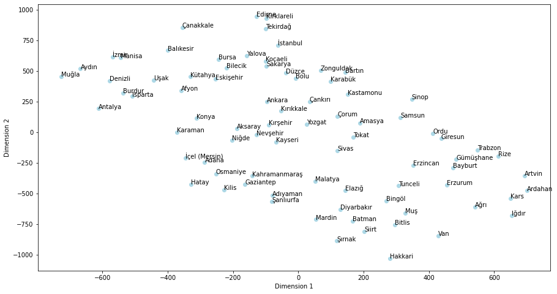

```python
f = plt.figure()
f.set_figwidth(15)
f.set_figheight(8)
plt.scatter(-distances.MDS1, -distances.MDS2,c='lightblue')
for i in range(len(mds_dim)):
    plt.annotate(cities[i], (-distances.MDS1[i],-distances.MDS2[i]))
plt.xlabel("Dimension 1")
plt.ylabel("Dimension 2")
plt.show()
```

The distance between some cities is seen more than usual. Mountainous regions may have caused this error.

## Task 3 – Dimensionality reduction for time series data

### Part a

```python
# X Train
x_train = pd.read_csv("uWaveGestureLibrary_X_TRAIN", header=None, sep=" ",prefix="t", skipinitialspace=True)
y_train = pd.read_csv("uWaveGestureLibrary_Y_TRAIN", header=None, sep=" ",prefix="t", skipinitialspace=True)
z_train = pd.read_csv("uWaveGestureLibrary_Z_TRAIN", header=None, sep=" ",prefix="t", skipinitialspace=True)
z_train.head(10)
```

|  | t0 | t1 | t2 | t3 | t4 | t5 | t6 | t7 | t8 | t9 | t10 | t11 | t12 | t13 | t14 | t15 | t16 | t17 | t18 | t19 | t20 | t21 | t22 | t23 | t24 | t25 | t26 | t27 | t28 | … |
| --- | --- | --- | --- | --- | --- | --- | --- | --- | --- | --- | --- | --- | --- | --- | --- | --- | --- | --- | --- | --- | --- | --- | --- | --- | --- | --- | --- | --- | --- | --- |
| 0 | 6.0 | -1.528965 | -1.528965 | -1.528965 | -1.528965 | -1.528965 | -1.528965 | -1.528965 | -1.528965 | -1.528965 | -1.528965 | -1.528965 | -1.528965 | -1.528965 | -1.528965 | -1.528965 | -1.528965 | -1.528965 | -1.528965 | -1.528965 | -1.518267 | -1.507569 | -1.489124 | -1.470679 | -1.452234 | -1.433789 | -1.423460 | -1.413131 | -1.413131 | … |
| 1 | 5.0 | 1.786869 | 1.786869 | 1.786869 | 1.786869 | 1.786869 | 1.786869 | 1.786869 | 1.786869 | 1.786869 | 1.786869 | 1.786869 | 1.786869 | 1.786869 | 1.786869 | 1.786869 | 1.786869 | 1.786869 | 1.786869 | 1.786869 | 1.786869 | 1.786869 | 1.769396 | 1.735905 | 1.700499 | 1.664659 | 1.628818 | 1.606211 | 1.603273 | … |
| 2 | 5.0 | 0.521249 | 0.521249 | 0.521249 | 0.521249 | 0.521249 | 0.521249 | 0.521249 | 0.521249 | 0.521249 | 0.521249 | 0.521249 | 0.521249 | 0.521249 | 0.521249 | 0.521249 | 0.521249 | 0.521249 | 0.521249 | 0.521249 | 0.521249 | 0.530693 | 0.547400 | 0.570613 | 0.593826 | 0.607308 | 0.613513 | 0.613513 | 0.613513 | … |
| 3 | 3.0 | 0.309455 | 0.309455 | 0.309455 | 0.309455 | 0.309455 | 0.309455 | 0.309455 | 0.309455 | 0.309455 | 0.309455 | 0.309455 | 0.309455 | 0.309455 | 0.309455 | 0.309455 | 0.309455 | 0.309455 | 0.309455 | 0.309455 | 0.309455 | 0.309455 | 0.309455 | 0.309455 | 0.309455 | 0.309455 | 0.309455 | 0.309455 | 0.309455 | … |
| 4 | 4.0 | -0.466022 | -0.466022 | -0.466022 | -0.466022 | -0.466022 | -0.466022 | -0.466022 | -0.466022 | -0.466022 | -0.466022 | -0.466022 | -0.466022 | -0.466022 | -0.466022 | -0.466022 | -0.466022 | -0.466022 | -0.466022 | -0.466022 | -0.466022 | -0.466022 | -0.466022 | -0.466022 | -0.466022 | -0.466022 | -0.466022 | -0.466022 | -0.466022 | … |
| 5 | 8.0 | 0.656401 | 0.656401 | 0.656401 | 0.656401 | 0.656401 | 0.656401 | 0.656401 | 0.656401 | 0.656401 | 0.656401 | 0.656401 | 0.656401 | 0.656401 | 0.656401 | 0.656401 | 0.656401 | 0.656401 | 0.656401 | 0.656401 | 0.656401 | 0.656401 | 0.656401 | 0.656401 | 0.656401 | 0.656401 | 0.656401 | 0.656401 | 0.656401 | … |
| 6 | 7.0 | 1.237417 | 1.237417 | 1.237417 | 1.237417 | 1.237417 | 1.237417 | 1.237417 | 1.237417 | 1.237417 | 1.237417 | 1.264204 | 1.305115 | 1.381742 | 1.468110 | 1.475307 | 1.475307 | 1.475307 | 1.475307 | 1.475307 | 1.475307 | 1.475307 | 1.493327 | 1.534239 | 1.564759 | 1.587488 | 1.594252 | 1.594252 | 1.610351 | … |
| 7 | 4.0 | -1.298718 | -1.298718 | -1.298718 | -1.298718 | -1.298718 | -1.298718 | -1.298718 | -1.298718 | -1.298718 | -1.298718 | -1.298718 | -1.298718 | -1.298718 | -1.298718 | -1.298718 | -1.298718 | -1.298718 | -1.298718 | -1.298718 | -1.298718 | -1.298718 | -1.298718 | -1.298718 | -1.298718 | -1.298718 | -1.298718 | -1.298718 | -1.298718 | … |
| 8 | 4.0 | -0.695129 | -0.695129 | -0.695129 | -0.695129 | -0.695129 | -0.695129 | -0.695129 | -0.695129 | -0.695129 | -0.695129 | -0.695129 | -0.695129 | -0.695129 | -0.695129 | -0.695129 | -0.695129 | -0.695129 | -0.695129 | -0.695129 | -0.695129 | -0.695129 | -0.695129 | -0.695129 | -0.695129 | -0.695129 | -0.695129 | -0.695129 | -0.695129 | … |
| 9 | 6.0 | -1.319491 | -1.319491 | -1.319491 | -1.319491 | -1.319491 | -1.319491 | -1.319491 | -1.319491 | -1.319491 | -1.319491 | -1.319491 | -1.319491 | -1.319491 | -1.319491 | -1.319491 | -1.319491 | -1.319491 | -1.319491 | -1.319491 | -1.319491 | -1.319491 | -1.319491 | -1.319491 | -1.319491 | -1.319491 | -1.319491 | -1.319491 | -1.319491 | … |

10 rows × 316 columns

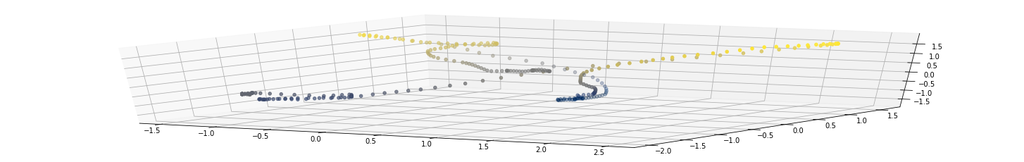

```python
# Class 1 visualization
X_values=x_train.iloc[10,1:]
Y_values=y_train.iloc[10,1:]
Z_values=z_train.iloc[10,1:]
class1_concat = pd.concat([X_values, Y_values, Z_values], axis=1)
# visualize axes and discriminate the initial point by setting it's size and color differently
from mpl_toolkits.mplot3d import Axes3D
fig = plt.figure()
ax = Axes3D(fig)

ax.scatter3D(X_values, Y_values, Z_values, c=Z_values, cmap='cividis');
```

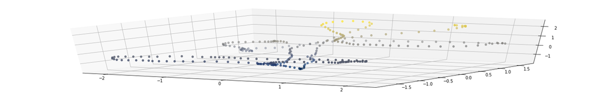

```python
# Class 2 visualization
X_values=x_train.iloc[14,1:]
Y_values=y_train.iloc[14,1:]
Z_values=z_train.iloc[14,1:]
class1_concat = pd.concat([X_values, Y_values, Z_values], axis=1)
# visualize axes and discriminate the initial point by setting it's size and color differently
from mpl_toolkits.mplot3d import Axes3D
fig = plt.figure()
ax = Axes3D(fig)

ax.scatter3D(X_values, Y_values, Z_values, c=Z_values, cmap='cividis');
```

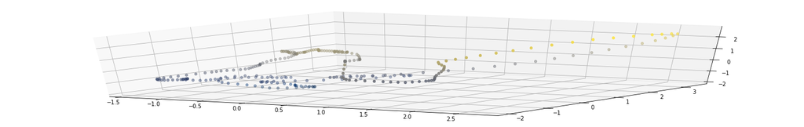

```python
# Class 3 visualization
X_values=x_train.iloc[3,1:]
Y_values=y_train.iloc[3,1:]
Z_values=z_train.iloc[3,1:]
class1_concat = pd.concat([X_values, Y_values, Z_values], axis=1)
# visualize axes and discriminate the initial point by setting it's size and color differently
from mpl_toolkits.mplot3d import Axes3D
fig = plt.figure()
ax = Axes3D(fig)

ax.scatter3D(X_values, Y_values, Z_values, c=Z_values, cmap='cividis');
```

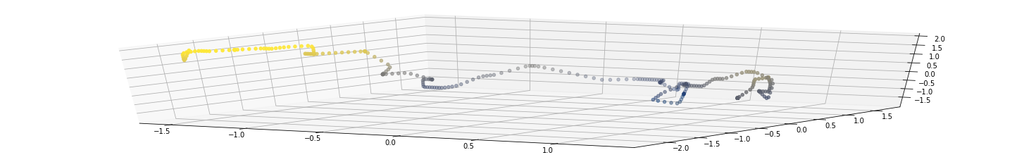

```python
# Class 4 visualization
X_values=x_train.iloc[4,1:]
Y_values=y_train.iloc[4,1:]
Z_values=z_train.iloc[4,1:]
class1_concat = pd.concat([X_values, Y_values, Z_values], axis=1)
# visualize axes and discriminate the initial point by setting it's size and color differently
from mpl_toolkits.mplot3d import Axes3D
fig = plt.figure()
ax = Axes3D(fig)

ax.scatter3D(X_values, Y_values, Z_values, c=Z_values, cmap='cividis');
```

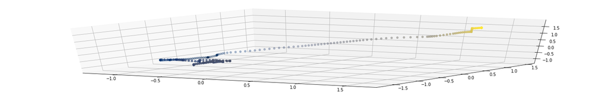

```python
# Class 5 visualization
X_values=x_train.iloc[1,1:]
Y_values=y_train.iloc[1,1:]
Z_values=z_train.iloc[1,1:]
class1_concat = pd.concat([X_values, Y_values, Z_values], axis=1)
# visualize axes and discriminate the initial point by setting it's size and color differently
from mpl_toolkits.mplot3d import Axes3D
fig = plt.figure()
ax = Axes3D(fig)

ax.scatter3D(X_values, Y_values, Z_values, c=Z_values, cmap='cividis');
```

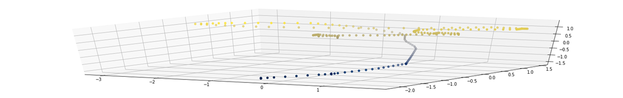

```python
# Class 6 visualization
X_values=x_train.iloc[0,1:]
Y_values=y_train.iloc[0,1:]
Z_values=z_train.iloc[0,1:]
class1_concat = pd.concat([X_values, Y_values, Z_values], axis=1)
# visualize axes and discriminate the initial point by setting it's size and color differently
from mpl_toolkits.mplot3d import Axes3D
fig = plt.figure()
ax = Axes3D(fig)

ax.scatter3D(X_values, Y_values, Z_values, c=Z_values, cmap='cividis');
```

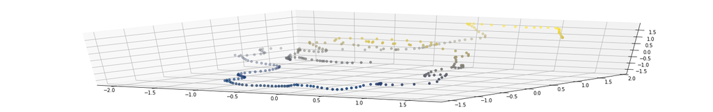

```python
# Class 7 visualization
X_values=x_train.iloc[6,1:]
Y_values=y_train.iloc[6,1:]
Z_values=z_train.iloc[6,1:]
class1_concat = pd.concat([X_values, Y_values, Z_values], axis=1)
# visualize axes and discriminate the initial point by setting it's size and color differently
from mpl_toolkits.mplot3d import Axes3D
fig = plt.figure()
ax = Axes3D(fig)

ax.scatter3D(X_values, Y_values, Z_values, c=Z_values, cmap='cividis');
```

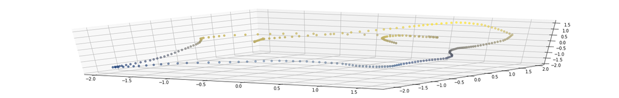

```python
# Class 8 visualization
X_values=x_train.iloc[5,1:]
Y_values=y_train.iloc[5,1:]
Z_values=z_train.iloc[5,1:]
class1_concat = pd.concat([X_values, Y_values, Z_values], axis=1)
# visualize axes and discriminate the initial point by setting it's size and color differently
from mpl_toolkits.mplot3d import Axes3D
fig = plt.figure()
ax = Axes3D(fig)

ax.scatter3D(X_values, Y_values, Z_values, c=Z_values, cmap='cividis');
```

### Part b

```python
x_train_1 = x_train.iloc[:,:]
y_train_1 = y_train.iloc[:,1:]
z_train_1 = z_train.iloc[:,1:]
concat_all = pd.concat([x_train_1, y_train_1, z_train_1], join="inner", axis=1)
print(concat_all.head())
concat_class1 = concat_all[concat_all["t0"]==1].drop(["t0"], axis=1)
concat_class2 = concat_all[concat_all["t0"]==2].drop(["t0"], axis=1)
concat_class3 = concat_all[concat_all["t0"]==3].drop(["t0"], axis=1)
concat_class4 = concat_all[concat_all["t0"]==4].drop(["t0"], axis=1)
concat_class5 = concat_all[concat_all["t0"]==5].drop(["t0"], axis=1)
concat_class6 = concat_all[concat_all["t0"]==6].drop(["t0"], axis=1)
concat_class7 = concat_all[concat_all["t0"]==7].drop(["t0"], axis=1)
concat_class8 = concat_all[concat_all["t0"]==8].drop(["t0"], axis=1)
```

```
    t0        t1        t2        t3  ...      t312      t313      t314      t315
0  6.0 -0.304243 -0.304243 -0.304243  ...  0.437632  0.419187  0.400743  0.382298
1  5.0  1.627311  1.627311  1.627311  ... -0.452667 -0.464613 -0.476560 -0.488507
2  5.0  0.661277  0.661277  0.661277  ... -0.862717 -0.862717 -0.862717 -0.862717
3  3.0  0.005185  0.005185  0.005185  ...  0.253740  0.445503  0.648538  0.851573
4  4.0  1.286198  1.286198  1.286198  ...  1.515219  1.632637  1.750054  1.867472

[5 rows x 946 columns]
```

```python
# Class 1
print(concat_class1)
rows = concat_class1.columns
class_observations = concat_class1.index
concat_class_T = concat_class1.T
pca = PCA(n_components = 2)
reduced_class = pd.DataFrame(pca.fit_transform(concat_class_T), index=rows, columns=["cmp1","cmp2"])
print(reduced_class.head())
print("a) How much variability can be recovered by the first two components?")
print(pca.explained_variance_ratio_)
eigenvectors = pd.DataFrame(pca.components_, index=["cmp1","cmp2"], columns=class_observations)
print("b)")
print(eigenvectors)
```

```
           t1        t2        t3  ...      t313      t314      t315
10  -0.791447 -0.791447 -0.795873  ...  0.005636  0.005636  0.005636
16  -0.449602 -0.449602 -0.449602  ...  0.961878  0.995555  1.029232
18  -0.187469 -0.187469 -0.187469  ...  0.321015  0.321015  0.321015
22   0.301482  0.301482  0.301482  ...  0.012593 -0.000146 -0.012885
37   0.163202  0.163202  0.163202  ...  0.423385  0.376644  0.329903
..        ...       ...       ...  ...       ...       ...       ...
865  0.948343  0.948343  0.948343  ...  0.487551  0.476105  0.464659
878  0.423145  0.423145  0.423145  ... -0.019088  0.021186  0.061460
883 -1.143164 -1.143164 -1.143164  ...  0.122305  0.094995  0.067684
885 -0.289544 -0.289544 -0.289544  ... -0.030765 -0.030765 -0.030765
892 -1.232590 -1.232590 -1.232590  ...  0.308207  0.320412  0.332617

[122 rows x 945 columns]
        cmp1      cmp2
t1 -3.688900 -5.182183
t2 -3.687540 -5.163230
t3 -3.692586 -5.144571
t4 -3.696911 -5.131040
t5 -3.697124 -5.124149
a) How much variability can be recovered by the first two components?
[0.52997902 0.10401207]
b)
           10        16        18   ...       883       885       892
cmp1  0.075076  0.096553  0.096187  ...  0.110183  0.110166  0.087095
cmp2  0.152411  0.076145 -0.045665  ...  0.055826  0.013741  0.146706

[2 rows x 122 columns]
```

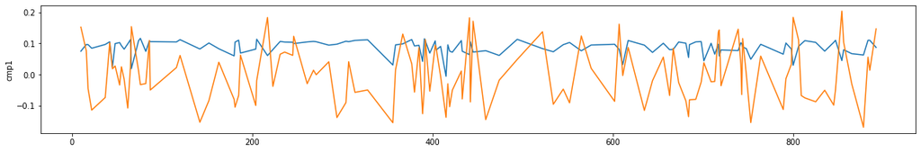

```python
sns.lineplot(x=eigenvectors.columns, y= eigenvectors.iloc[0])
sns.lineplot(x=eigenvectors.columns, y= eigenvectors.iloc[1])
```

```python
# Class 2
print(concat_class2)
rows = concat_class2.columns
class_observations = concat_class2.index
concat_class_T = concat_class2.T
pca = PCA(n_components = 2)
reduced_class = pd.DataFrame(pca.fit_transform(concat_class_T), index=rows, columns=["cmp1","cmp2"])
print(reduced_class.head())
print("a) How much variability can be recovered by the first two components?")
print(pca.explained_variance_ratio_)
eigenvectors = pd.DataFrame(pca.components_, index=["cmp1","cmp2"], columns=class_observations)
print("b)")
print(eigenvectors)
```

```
           t1        t2        t3  ...      t313      t314      t315
14   1.199507  1.199507  1.233217  ...  0.549871  0.514492  0.443659
19   0.138576  0.138576  0.138576  ...  0.195265  0.126415  0.057565
28   0.412833  0.412833  0.412833  ... -0.105930 -0.083677 -0.065066
30   0.023970  0.023970  0.023970  ...  0.066249  0.038811 -0.022410
57  -1.197755 -1.197755 -1.197755  ... -0.099884 -0.099884 -0.099884
..        ...       ...       ...  ...       ...       ...       ...
873  1.082807  1.082807  1.082807  ... -0.024033 -0.023739 -0.023739
876  1.439248  1.439248  1.439248  ... -0.104733 -0.106934 -0.106934
879 -0.029715 -0.029715 -0.029715  ... -0.093781 -0.093781 -0.093781
886  0.550959  0.550959  0.550959  ...  0.015097  0.040224  0.065350
893  0.282877  0.282877  0.282877  ...  0.158608  0.223306  0.267828

[108 rows x 945 columns]
        cmp1      cmp2
t1  1.918124  0.642519
t2  1.938541  0.628091
t3  1.958969  0.622781
t4  1.977396  0.619205
t5  1.988042  0.612277
a) How much variability can be recovered by the first two components?
[0.52712574 0.15491441]
b)
           14        19        28   ...       879       886       893
cmp1  0.115856  0.083753  0.108120  ...  0.117277  0.102014  0.001352
cmp2  0.039025  0.124100 -0.102249  ... -0.085386  0.078678 -0.125408

[2 rows x 108 columns]
```

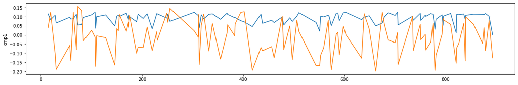

```python
sns.lineplot(x=eigenvectors.columns, y= eigenvectors.iloc[0])
sns.lineplot(x=eigenvectors.columns, y= eigenvectors.iloc[1])
```

```python
# Class 3
print(concat_class3)
rows = concat_class3.columns
class_observations = concat_class3.index
concat_class_T = concat_class3.T
pca = PCA(n_components = 2)
reduced_class = pd.DataFrame(pca.fit_transform(concat_class_T), index=rows, columns=["cmp1","cmp2"])
print(reduced_class.head())
print("a) How much variability can be recovered by the first two components?")
print(pca.explained_variance_ratio_)
eigenvectors = pd.DataFrame(pca.components_, index=["cmp1","cmp2"], columns=class_observations)
print("b)")
print(eigenvectors)
```

```
           t1        t2        t3  ...      t313      t314      t315
3    0.005185  0.005185  0.005185  ...  0.445503  0.648538  0.851573
12  -0.595755 -0.595755 -0.595755  ... -0.564912 -0.547859 -0.530806
26  -0.690376 -0.690376 -0.690376  ... -0.014693 -0.477508 -0.940324
60  -1.045879 -1.045879 -1.045879  ... -0.396182 -0.367657 -0.339132
79  -1.235182 -1.235182 -1.235182  ... -1.555118 -1.487420 -1.419722
..        ...       ...       ...  ...       ...       ...       ...
871 -1.611903 -1.611903 -1.611903  ... -0.697332 -0.800875 -0.904417
874 -0.848724 -0.848724 -0.848724  ...  1.271007  1.045327  0.819647
882 -1.648775 -1.648775 -1.648775  ...  0.212675  0.143211  0.073747
887 -0.055721 -0.055721 -0.055721  ... -2.375567 -2.422770 -2.469972
891  0.117811  0.117811  0.117811  ...  0.139163  0.176614  0.214065

[106 rows x 945 columns]
        cmp1      cmp2
t1 -8.286247  3.608272
t2 -8.290376  3.615231
t3 -8.294505  3.622189
t4 -8.298634  3.629148
t5 -8.301420  3.632934
a) How much variability can be recovered by the first two components?
[0.41132921 0.18358206]
b)
           3         12        26   ...       882       887       891
cmp1  0.025085  0.122837  0.097231  ...  0.052058  0.071206  0.093981
cmp2  0.002939  0.027497  0.058415  ... -0.191313  0.164026  0.043207

[2 rows x 106 columns]
```

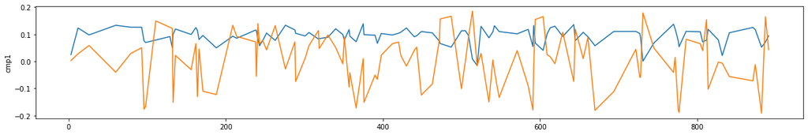

```python
sns.lineplot(x=eigenvectors.columns, y= eigenvectors.iloc[0])
sns.lineplot(x=eigenvectors.columns, y= eigenvectors.iloc[1])
```

```python
# Class 4
print(concat_class4)
rows = concat_class4.columns
class_observations = concat_class4.index
concat_class_T = concat_class4.T
pca = PCA(n_components = 2)
reduced_class = pd.DataFrame(pca.fit_transform(concat_class_T), index=rows, columns=["cmp1","cmp2"])
print(reduced_class.head())
print("a) How much variability can be recovered by the first two components?")
print(pca.explained_variance_ratio_)
eigenvectors = pd.DataFrame(pca.components_, index=["cmp1","cmp2"], columns=class_observations)
print("b)")
print(eigenvectors)
```

```
           t1        t2        t3  ...      t313      t314      t315
4    1.286198  1.286198  1.286198  ...  1.632637  1.750054  1.867472
7    0.305303  0.305303  0.305303  ... -0.319849 -0.374539 -0.429228
8    0.980810  0.980810  0.980810  ... -1.217694 -1.329333 -1.440972
33   0.542374  0.542374  0.542374  ...  0.421125  0.421125  0.421125
50   1.184522  1.184522  1.184522  ...  1.294166  1.276625  1.259084
..        ...       ...       ...  ...       ...       ...       ...
848  0.999407  0.999407  0.999407  ...  0.978468  1.027221  1.075974
850  1.075945  1.075945  1.075945  ... -2.156819 -2.156819 -2.156819
859  0.365053  0.365053  0.365053  ... -0.182826 -0.236873 -0.290920
872  0.525055  0.525055  0.525055  ...  0.423268  0.423268  0.423268
888  0.940879  0.940879  0.940879  ... -0.944866 -0.944866 -0.944866

[110 rows x 945 columns]
        cmp1      cmp2
t1 -9.673091 -3.227804
t2 -9.674213 -3.227425
t3 -9.675334 -3.227046
t4 -9.666724 -3.216117
t5 -9.656793 -3.204064
a) How much variability can be recovered by the first two components?
[0.41372499 0.13175833]
b)
           4         7         8    ...       859       872       888
cmp1 -0.125355 -0.063025 -0.127421  ... -0.090316 -0.105357 -0.116453
cmp2  0.048033  0.185190  0.047966  ...  0.008062  0.028861  0.064334

[2 rows x 110 columns]
```

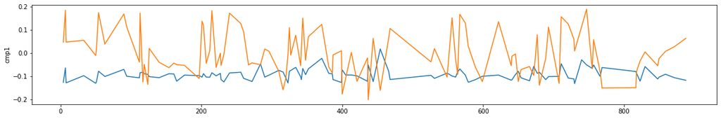

```python
sns.lineplot(x=eigenvectors.columns, y= eigenvectors.iloc[0])
sns.lineplot(x=eigenvectors.columns, y= eigenvectors.iloc[1])
```

```python
# Class 5
print(concat_class5)
rows = concat_class5.columns
class_observations = concat_class5.index
concat_class_T = concat_class5.T
pca = PCA(n_components = 2)
reduced_class = pd.DataFrame(pca.fit_transform(concat_class_T), index=rows, columns=["cmp1","cmp2"])
print(reduced_class.head())
print("a) How much variability can be recovered by the first two components?")
print(pca.explained_variance_ratio_)
eigenvectors = pd.DataFrame(pca.components_, index=["cmp1","cmp2"], columns=class_observations)
print("b)")
print(eigenvectors)
```

```
           t1        t2        t3  ...      t313      t314      t315
1    1.627311  1.627311  1.627311  ... -0.464613 -0.476560 -0.488507
2    0.661277  0.661277  0.661277  ... -0.862717 -0.862717 -0.862717
13  -0.172713 -0.172713 -0.172713  ... -1.138478 -1.138478 -1.138478
34  -0.105094 -0.105094 -0.105094  ... -0.891975 -0.873493 -0.855012
40  -0.080211 -0.080211 -0.080211  ... -1.608862 -1.654410 -1.699958
..        ...       ...       ...  ...       ...       ...       ...
867 -0.072716 -0.072716 -0.072716  ... -0.486154 -0.499657 -0.513160
870  0.974109  0.974109  0.974109  ... -0.610914 -0.614966 -0.619017
884 -1.020162 -1.020162 -1.020162  ... -0.623964 -0.623964 -0.623964
890 -1.122223 -1.122223 -1.122223  ... -1.196746 -1.196746 -1.196746
895 -0.168518 -0.168518 -0.168518  ... -0.800426 -0.768603 -0.736781

[127 rows x 945 columns]
        cmp1      cmp2
t1 -3.376271 -6.157296
t2 -3.377664 -6.180765
t3 -3.379058 -6.204234
t4 -3.381819 -6.228253
t5 -3.391543 -6.257520
a) How much variability can be recovered by the first two components?
[0.52631191 0.12721762]
b)
           1         2         13   ...       884       890       895
cmp1 -0.096247 -0.093701 -0.022707  ... -0.076414 -0.078943 -0.097093
cmp2 -0.003616 -0.073773 -0.120110  ...  0.097221  0.177133  0.022710

[2 rows x 127 columns]
```

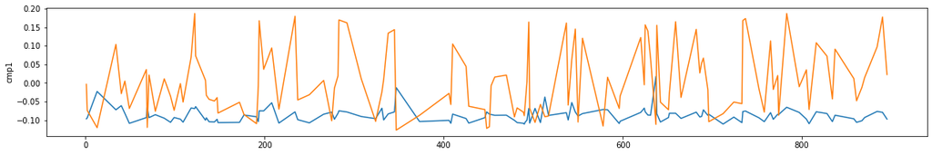

```python
sns.lineplot(x=eigenvectors.columns, y= eigenvectors.iloc[0])
sns.lineplot(x=eigenvectors.columns, y= eigenvectors.iloc[1])
```

```python
# Class 6
print(concat_class6)
rows = concat_class6.columns
class_observations = concat_class6.index
concat_class_T = concat_class6.T
pca = PCA(n_components = 2)
reduced_class = pd.DataFrame(pca.fit_transform(concat_class_T), index=rows, columns=["cmp1","cmp2"])
print(reduced_class.head())
print("a) How much variability can be recovered by the first two components?")
print(pca.explained_variance_ratio_)
eigenvectors = pd.DataFrame(pca.components_, index=["cmp1","cmp2"], columns=class_observations)
print("b)")
print(eigenvectors)
```

```
           t1        t2        t3  ...      t313      t314      t315
0   -0.304243 -0.304243 -0.304243  ...  0.419187  0.400743  0.382298
9   -1.177078 -1.177078 -1.177078  ...  1.198000  1.212849  1.227698
15   0.820518  0.820518  0.820518  ...  0.583540  0.571973  0.560407
17  -0.135626 -0.135626 -0.135626  ...  1.898864  1.919255  1.939646
21   1.588075  1.588075  1.588075  ...  0.428625  0.456835  0.485045
..        ...       ...       ...  ...       ...       ...       ...
862  1.099546  1.099546  1.099546  ...  0.866983  0.905573  0.944162
863  1.179545  1.179545  1.179545  ...  0.753837  0.738838  0.723838
875 -0.276411 -0.276411 -0.276411  ...  1.261701  1.298762  1.335823
880  0.703685  0.703685  0.703685  ...  0.394524  0.366700  0.338875
889  0.452726  0.452726  0.452726  ...  0.306291  0.281161  0.256031

[111 rows x 945 columns]
        cmp1      cmp2
t1 -2.925098  0.002436
t2 -2.909842  0.010310
t3 -2.894586  0.018184
t4 -2.882846  0.029280
t5 -2.889014  0.045163
a) How much variability can be recovered by the first two components?
[0.42327801 0.11671467]
b)
           0         9         15   ...       875       880       889
cmp1 -0.095928 -0.098013 -0.121353  ... -0.107839 -0.108530 -0.107489
cmp2  0.131185  0.025138  0.002007  ... -0.032765  0.068246 -0.082207

[2 rows x 111 columns]
```

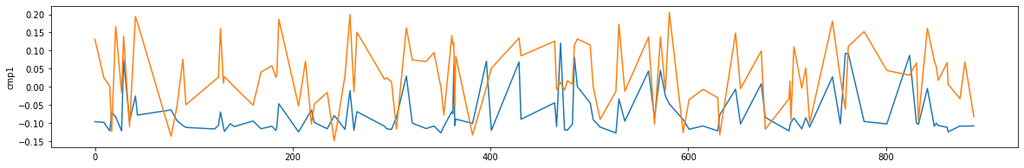

```python
sns.lineplot(x=eigenvectors.columns, y= eigenvectors.iloc[0])
sns.lineplot(x=eigenvectors.columns, y= eigenvectors.iloc[1])
```

```python
# Class 7
print(concat_class7)
rows = concat_class7.columns
class_observations = concat_class7.index
concat_class_T = concat_class7.T
pca = PCA(n_components = 2)
reduced_class = pd.DataFrame(pca.fit_transform(concat_class_T), index=rows, columns=["cmp1","cmp2"])
print(reduced_class.head())
print("a) How much variability can be recovered by the first two components?")
print(pca.explained_variance_ratio_)
eigenvectors = pd.DataFrame(pca.components_, index=["cmp1","cmp2"], columns=class_observations)
print("b)")
print(eigenvectors)
```

```
           t1        t2        t3  ...      t313      t314      t315
6    1.474328  1.474328  1.474328  ... -0.121164 -0.067947 -0.011505
11   0.037098  0.037098  0.037098  ...  0.642856  0.631389  0.619922
23   0.511061  0.511061  0.511061  ... -0.040737 -0.040682 -0.040682
25  -0.743273 -0.743273 -0.743273  ... -0.041706 -0.046056 -0.050407
31   1.074161  1.074161  1.074161  ...  0.940940  0.940940  0.940940
..        ...       ...       ...  ...       ...       ...       ...
864  1.177669  1.177669  1.177669  ... -0.135647 -0.128856 -0.128856
868  1.235839  1.235839  1.235839  ... -0.250632 -0.250632 -0.250632
869  1.248818  1.248818  1.248818  ...  0.812427  0.726897  0.641367
877  0.491277  0.491277  0.491277  ...  0.143656  0.032559 -0.081141
894  1.248704  1.248704  1.248704  ... -0.549343 -0.505912 -0.433044

[112 rows x 945 columns]
        cmp1      cmp2
t1 -6.381459 -1.505416
t2 -6.374403 -1.501035
t3 -6.369851 -1.501183
t4 -6.373873 -1.507728
t5 -6.372642 -1.519887
a) How much variability can be recovered by the first two components?
[0.49705099 0.16381657]
b)
           6         11        23   ...       869       877       894
cmp1 -0.108425 -0.101939 -0.088537  ... -0.092569 -0.099668 -0.115425
cmp2  0.071238 -0.095879  0.051607  ... -0.120195 -0.095887  0.068440

[2 rows x 112 columns]
```

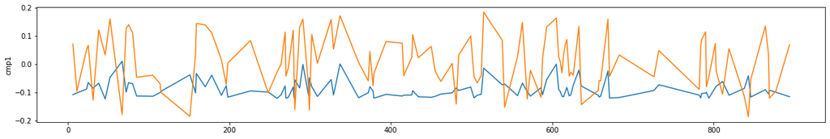

```python
sns.lineplot(x=eigenvectors.columns, y= eigenvectors.iloc[0])
sns.lineplot(x=eigenvectors.columns, y= eigenvectors.iloc[1])
```

```python
# Class 8
print(concat_class8)
rows = concat_class8.columns
class_observations = concat_class8.index
concat_class_T = concat_class8.T
pca = PCA(n_components = 2)
reduced_class = pd.DataFrame(pca.fit_transform(concat_class_T), index=rows, columns=["cmp1","cmp2"])
print(reduced_class.head())
print("a) How much variability can be recovered by the first two components?")
print(pca.explained_variance_ratio_)
eigenvectors = pd.DataFrame(pca.components_, index=["cmp1","cmp2"], columns=class_observations)
print("b)")
print(eigenvectors)
```

```
           t1        t2        t3  ...      t313      t314      t315
5   -0.479252 -0.479252 -0.479252  ...  0.419203  0.370431  0.321659
20  -0.500566 -0.500566 -0.500566  ... -0.244358 -0.241102 -0.241102
24  -0.634362 -0.634362 -0.634362  ...  0.350394  0.293724  0.237053
32   1.049197  1.062133  1.075070  ...  0.276625  0.247094  0.217563
36  -0.202384 -0.202384 -0.202384  ...  0.129457  0.151402  0.171800
..        ...       ...       ...  ...       ...       ...       ...
852  0.680496  0.680496  0.680496  ... -0.065182 -0.065182 -0.065182
857 -0.727320 -0.727320 -0.727320  ...  0.159886  0.164342  0.164342
860 -1.155908 -1.155908 -1.155908  ...  0.205758  0.306585  0.407413
866 -0.951032 -0.951032 -0.951032  ...  0.098046  0.065343  0.032641
881 -0.301332 -0.301332 -0.301332  ...  0.664618  0.646384  0.631005

[100 rows x 945 columns]
        cmp1      cmp2
t1  5.437257 -0.294532
t2  5.453201 -0.284501
t3  5.470024 -0.274171
t4  5.477725 -0.264384
t5  5.477927 -0.264962
a) How much variability can be recovered by the first two components?
[0.4774311  0.26678782]
b)
           5         20        24   ...       860       866       881
cmp1 -0.089342 -0.114775 -0.123945  ... -0.126855 -0.113655 -0.088294
cmp2  0.128689 -0.068692  0.032983  ... -0.006228  0.052469  0.138373

[2 rows x 100 columns]
```

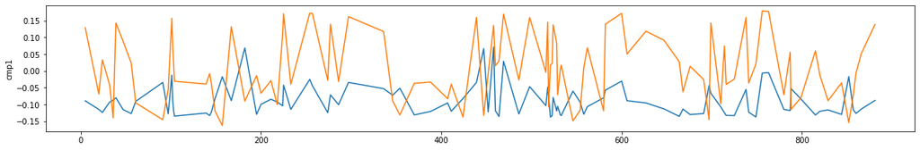

```python
sns.lineplot(x=eigenvectors.columns, y= eigenvectors.iloc[0])
sns.lineplot(x=eigenvectors.columns, y= eigenvectors.iloc[1])
```

```python
%%shell
jupyter nbconvert --to html /content/IE582_HW1_Cumhur_Kılıç.ipynb
```